# Predicción de nacimientos en Colombia

## Participantes

- Bechara, Hermes (hacordoba77@unisalle.edu.co)
- Liscano, Andrés (aliscano20@unisalle.edu.co)
- Montealegre, Efrain (emontealegre19@unisalle.edu.co)

# Introducción

Este proyecto tiene como propósito desarrollar un modelo de Machine Learning capaz de predecir las tasas de natalidad en Colombia, utilizando datos históricos proporcionados por el DANE. La capacidad de predecir nacimientos es crucial para la planificación de políticas públicas en áreas como la salud, la educación y la infraestructura, así como para la toma de decisiones estratégicas en diversos sectores.

El modelo se construirá a partir de un análisis exhaustivo de los datos de nacimientos, identificando patrones y factores que influyen en la natalidad. Se utilizarán técnicas de preprocesamiento, exploración de datos, selección de modelos, entrenamiento y evaluación para asegurar la robustez y precisión de las predicciones.

## Principales librerías utilizadas:

- pandas: Para la manipulación y análisis de datos estructurados.
- numpy: Para operaciones numéricas eficientes, especialmente con arreglos.
- matplotlib.pyplot: Para la creación de visualizaciones estáticas y dinámicas.
- seaborn: Basado en matplotlib, para crear gráficos estadísticos atractivos e informativos.
- sklearn (scikit-learn): Una librería completa para Machine Learning, incluyendo herramientas para preprocesamiento, selección de modelos, entrenamiento y evaluación.

## Datos utilizados:

Se utilizarán los siguientes archivos CSV, que contienen datos de nacimientos en Colombia para los años 2020, 2021, 2022 y 2023:

- [Estadísticas Vitales - EEVV – 2020](https://microdatos.dane.gov.co/index.php/catalog/732)
- [Estadísticas Vitales - EEVV – 2021](https://microdatos.dane.gov.co/index.php/catalog/775)
- [Estadísticas Vitales - EEVV – 2022](https://microdatos.dane.gov.co/index.php/catalog/807)
- [Estadísticas Vitales - EEVV – 2023](https://microdatos.dane.gov.co/index.php/catalog/843)

> Fuente: Departamento Administrativo Nacional de Estadística: www.dane.gov.co. Queda en cambio prohibida la copia o reproducción de los datos en cualquier medio electrónico (redes, bases de datos, cd rom, diskettes) que permita la disponibilidad de esta información a múltiples usuarios sin el previo visto bueno del DANE por medio escrito.

## Variables DANE

Descripción general de las variables obtenidas de los microdatos del DANE. Ver el diccionario de datos completo

| Variable | Etiqueta | Concepto |
| --- | --- | --- |
| COD_DPTO | Departamento de Nacimiento | Departamento de Nacimiento Código, según la División Político- Administrativa del DANE. 05= Antioquia 08= Atlántico 11= Bogotá 13= Bolivar 15= Boyaca 17=Caldas 18= Caqueta 19=Cauca 20= Cesar 23= Cordo… |
| COD_MUNIC | Municipio de Nacimiento | Municipio de Nacimiento Código, según la División Político- Administrativa del DANE. |
| AREANAC | Área del Nacimiento | Área del Nacimiento 1 = Cabecera municipal 2 = Centro poblado (Inspección, corregimiento o caserío) 3 = Rural disperso 9 = Sin información |
| SIT_PARTO | Sitio de la Parto | Sitio de la Parto 1 = Institución de salud 2 = Domicilio 3 = Otro 9 = Sin información |
| OTRO_SIT | Otro sitio, ¿cuál? | Otro sitio, ¿cuál? |
| SEXO | Sexo del nacido vivo | Sexo del nacido vivo 1 = Masculino 2 = Femenino 3= Indeterminado |
| PESO_NAC | Peso del nacido vivo, al nacer | Peso del nacido vivo, al nacer 1 = Menos de 1.000 2 = 1.000 - 1.499 3 = 1.500 - 1.999 4 = 2.000 - 2499 5 = 2.500 - 2.999 6 = 3.000 - 3499 7 = 3.500 - 3.999 8 = 4.000 y más 9 = Sin información |
| TALLA_NAC | Talla del nacido vivo, al nacer | Talla del nacido vivo, al nacer 1 = Menos de 20 2 = 20-29 3 = 30-39 4 = 40-49 5 = 50-59 6 = 60 y Más. 9 = Sin información |
| ANO | Año de la ocurrencia | Año de la ocurrencia 2023 |
| MES | Mes de la ocurrencia | Mes de la ocurrencia 01 = Enero 02 = Febrero 03 = Marzo 04 = Abril 05 = Mayo 06 = Junio 07 = Julio 08 = Agosto 09 = Septiembre 10 = Octubre 11 = Noviembre 12 = Diciembre |
| ATEN_PAR | El parto fue atendido por | El parto fue atendido por 1 = Médico 2 = Enfermero(a) 3 = Auxiliar de enfermería 4 = Promotor(a) de salud 5 = Partera 6 = Otro persona 9 = Sin información |
| T_GES | Tiempo de gestación del nacido vivo | Tiempo de gestación del nacido vivo 1 = Menos de 22 2 = De 22 a 27 3 = De 28 a 37 4 = De 38 a 41 5 = De 42 y más 6 = Ignorado 9 = Sin información |
| T_GES_AGRU_CIE | Tiempo de gestación del nacido vivo ajustado a la agrupación sugerida por la CIE | Tiempo de gestación del nacido vivo ajustado a la agrupación sugerida por la CIE 1 = Menos de 22 2 = De 22 a 27 3 = De 28 a 36 4 = De 37 a 41 5 = De 42 y más 6 = Ignorado 9 = Sin información |
| NUMCONSUL | Número de consultas prenatales que tuvo la madre del nacido vivo | Número de consultas prenatales que tuvo la madre del nacido vivo 00= Ninguna 99 = Sin información |
| TIPO_PARTO | Tipo de parto de este nacimiento | Tipo de parto de este nacimiento 1 = Espontáneo 2 = Cesárea 3 = Instrumentado 4 = Ignorado 9 = Sin información |
| MUL_PARTO | Multiplicidad del embarazo | Multiplicidad del embarazo 1 = Simple 2 = Doble 3 = Triple 4 = Cuádruple o más 9 = Sin información |
| APGAR1 | APGAR al minuto del nacido vivo | APGAR al minuto del nacido vivo 01 - 10 = Al minuto 99 = sin información |
| APGAR2 | APGAR a los cinco minutos del nacido vivo | APGAR a los cinco minutos del nacido vivo 01 - 10 = A los cinco minutos 99 = sin información |
| IDHEMOCLAS | Hemoclasificación del nacido vivo: Grupo Sanguíneo | Hemoclasificación del nacido vivo: Grupo Sanguíneo 1 = A 2 = B 3 = O 4 = AB 9 = Sin información |
| IDFACTORRH | Hemoclasificación del nacido vivo: Factor RH | Hemoclasificación del nacido vivo: Factor RH 1 = Positivo 2 = Negativo 9= Sin información |
| IDPERTET | De acuerdo con la cultura, pueblo o rasgos físicos, el nacido vivo es reconocido por sus padres como | De acuerdo con la cultura, pueblo o rasgos físicos, el nacido vivo es reconocido por sus padres como 1 = Indígena 2 = Rom (Gitano) 3 = Raizal del archipiélago de San Andrés y Providencia 4 = Palenquer… |
| EDAD_MADRE | Edad de la madre a la fecha del parto | Edad de la madre a la fecha del parto 1 = De 10-14 Años 2 = De 15-19 Años 3 = De 20-24 Años 4 = De 25-29 Años 5 = De 30-34 Años 6 = De 35-39 Años 7 = De 40-44 Años 8 = De 45-49 Años 9 = De 50-54 Años … |
| EST_CIVM | Estado conyugal de la madre | Estado conyugal de la madre 1 = No está casada y lleva dos o más años viviendo con su pareja 2 = No está casada y lleva menos de dos años viviendo con su pareja 3 = Está separada, divorciada 4 = Está … |
| NIV_EDUM | Ultimo nivel de estudio que aprobó la madre | Nivel educativo del la madre 1 = Preescolar 2 = Básica primaria 3 = Básica secundaria 4 = Media académica o clásica 5 = Media técnica 6 = Normalista 7 = Técnica profesional 8 = Tecnológica 9 = Profesi… |
| ULTCURMAD | Ultimo año o grado aprobado de la madre | Ultimo año o grado aprobado de la madre 99 = Sin información. |
| CODPRES | País de residencia habitual de la madre en el extranjero | País de residencia habitual de la madre en el extranjero Código, según listado de países ISO 3166/2 |
| CODPTORE | Departamento de residencia habitual de la madre | Departamento de residencia habitual de la madre Código, según la División Político- Administrativa del DANE. |
| CODMUNRE | Municipio de residencia habitual de la madre | Municipio de residencia habitual de la madre Municipio de residencia habitual, según la División Político- Administrativa del DANE |
| AREA_RES | Área de residencia habitual de la madre | Área de residencia habitual de la madre 1 = Cabecera municipal 2 = Centro poblado (inspección, corregimiento o caserío) 3 = Rural disperso 9 = Sin información |
| N_HIJOSV | Número de hijos nacidos vivos que ha tenido la madre, incluido el presente | Número de hijos nacidos vivos que ha tenido la madre, incluido el presente 1 = 1 hijo 2 = 2 hijos 3 = 3 hijos 4 = 4 hijos 5 = 5 hijos 6 = 6 hijos 7 = 7 hijos 8 = 8 hijos 9 = 9 hijos 10 = 10 hijos 11 =… |
| FECHA_NACM | Fecha de nacimiento del anterior hijo nacido vivo | Fecha de nacimiento del anterior hijo nacido vivo |
| N_EMB | Número de embarazos, incluido el presente | Número de embarazos, incluido el presente 99 = Sin información |
| SEG_SOCIAL | Régimen de seguridad social en salud de la madre | Régimen de seguridad social en salud de la madre 1 = Contributivo 2 = Subsidiado 3 = Excepción 4 = Especial 5 = No asegurado 9 = Sin información |
| IDCLASADMI | Entidad Administradora en Salud a la que pertenece la madre | Entidad Administradora en Salud a la que pertenece la madre 1 = Entidad promotora de salud 2 = Entidad promotora de salud - Subsidiado 3 = Entidad adaptada de salud 4 = Entidad especial de salud 5 = E… |
| EDAD_PADRE | Edad del padre en años cumplidos a la fecha del nacimiento de este hijo | Edad del padre en años cumplidos a la fecha del nacimiento de este hijo 999 = Sin información |
| ULTCURPAD | Ultimo año o grado aprobado del padre | Último año o grado aprobado del nivel educativo del padre 99 = Sin información |
| PROFESION | Profesión de quien certifica el nacimiento | Profesión de quien certifica el nacimiento 1 = Médico 2 = Enfermero(a) 3 = Auxiliar de enfermería 4 = Promotor(a) de salud 5 = Funcionario de registro civil 9= Sin Información |
| TIPOFORMULARIO | Fuente del Certificado | Tipo de formulario para la captura de información 1 = Certificado RUAF-ND 2 = Formato de Notificación Étnica 3 = Recuperación cruce RNEC |

# Importación de librerías

```python
import pandas as pd
import numpy as np
import matplotlib.pyplot as plt
import seaborn as sns
from sklearn.ensemble import RandomForestRegressor
from sklearn.metrics import mean_absolute_error, mean_squared_error, r2_score

# Configuración para visualizaciones
sns.set_style("whitegrid")
plt.rcParams['figure.figsize'] = (12, 6)
plt.rcParams['font.size'] = 12
```

# Preprocesamiento de los datos

Esta sección detalla el proceso de carga, combinación y limpieza de los datos de nacimientos. Es fundamental preparar los datos adecuadamente para asegurar la calidad y fiabilidad del modelo de Machine Learning.

```python
# Rutas de los archivos CSV
file_paths = {
    '2020': './data/nac2020.csv',
    '2021': './data/nac2021.csv',
    '2022': './data/nac2022.csv',
    '2023': './data/BD-EEVV-Nacimientos-2023.csv'
}

# Lista para almacenar los DataFrames individuales
dfs = []

# Cargar cada archivo CSV
for year, path in file_paths.items():
    try:
        # Intentar leer con codificación 'latin1' (común en archivos de datos de Latinoamérica)
        df = pd.read_csv(path, encoding='latin1', low_memory=False)
        dfs.append(df)
        print(f"Cargado {path} con {len(df)} filas.")
    except FileNotFoundError:
        print(f"Error: El archivo {path} no fue encontrado. Asegúrate de que está en la misma carpeta.")
    except UnicodeDecodeError:
        print(f"Error de decodificación Unicode para {path}. Intentando con otra codificación o revisa el archivo.")
    except Exception as e:
        print(f"Error al cargar {path}: {e}")

# Concatenar todos los DataFrames en uno solo
if dfs:
    df_combined = pd.concat(dfs, ignore_index=True)
    print(f"\nTotal de filas combinadas: {len(df_combined)}")
else:
    df_combined = pd.DataFrame()
    print("No se pudo cargar ningún archivo CSV.")

# Mostrar las primeras filas del DataFrame combinado
print("\nPrimeras 5 filas del DataFrame combinado:")
df_combined.head()
```

```
Cargado ./data/nac2020.csv con 629402 filas.
Cargado ./data/nac2021.csv con 616914 filas.
Cargado ./data/nac2022.csv con 573625 filas.
Cargado ./data/BD-EEVV-Nacimientos-2023.csv con 515549 filas.

Total de filas combinadas: 2335490

Primeras 5 filas del DataFrame combinado:
```

|  | COD_DPTO | COD_MUNIC | AREANAC | SIT_PARTO | OTRO_SIT | SEXO | PESO_NAC | TALLA_NAC | ANO | MES | ... | FECHA_NACM | N_EMB | SEG_SOCIAL | IDCLASADMI | EDAD_PADRE | NIV_EDUP | ULTCURPAD | PROFESION | T_GES_AGRU_CIE | TIPOFORMULARIO |
| --- | --- | --- | --- | --- | --- | --- | --- | --- | --- | --- | --- | --- | --- | --- | --- | --- | --- | --- | --- | --- | --- |
| 0 | 44 | 560 | 3 | 2 | NaN | 2 | 9 | 9 | 2020 | 11 | ... | NaN | 1 | 2 | 2.0 | 20 | 99 | 99 | 5.0 | NaN | NaN |
| 1 | 44 | 560 | 3 | 2 | NaN | 1 | 9 | 9 | 2020 | 10 | ... | NaN | 1 | 2 | 2.0 | 20 | 99 | 99 | 5.0 | NaN | NaN |
| 2 | 44 | 560 | 3 | 2 | NaN | 1 | 9 | 9 | 2020 | 10 | ... | NaN | 1 | 2 | 2.0 | 20 | 99 | 99 | 5.0 | NaN | NaN |
| 3 | 44 | 560 | 3 | 2 | NaN | 2 | 9 | 9 | 2020 | 4 | ... | NaN | 1 | 2 | 2.0 | 20 | 99 | 99 | 5.0 | NaN | NaN |
| 4 | 44 | 560 | 3 | 2 | NaN | 2 | 9 | 9 | 2020 | 8 | ... | NaN | 1 | 2 | 2.0 | 20 | 99 | 99 | 5.0 | NaN | NaN |

5 rows × 39 columns

```python
df_combined.describe()
```

|  | COD_DPTO | COD_MUNIC | AREANAC | SIT_PARTO | SEXO | PESO_NAC | TALLA_NAC | ANO | MES | ATEN_PAR | ... | N_HIJOSV | N_EMB | SEG_SOCIAL | IDCLASADMI | EDAD_PADRE | NIV_EDUP | ULTCURPAD | PROFESION | T_GES_AGRU_CIE | TIPOFORMULARIO |
| --- | --- | --- | --- | --- | --- | --- | --- | --- | --- | --- | --- | --- | --- | --- | --- | --- | --- | --- | --- | --- | --- |
| count | 2.335490e+06 | 2.335490e+06 | 2.335490e+06 | 2.335490e+06 | 2.335490e+06 | 2.335490e+06 | 2.335490e+06 | 2.335490e+06 | 2.335490e+06 | 2.335490e+06 | ... | 2.335490e+06 | 2.335490e+06 | 2.335490e+06 | 2.133265e+06 | 2.335490e+06 | 2.335490e+06 | 2.335490e+06 | 2.328739e+06 | 1.706088e+06 | 1.706088e+06 |
| mean | 3.429114e+01 | 1.651475e+02 | 1.059588e+00 | 1.045462e+00 | 1.487766e+00 | 5.714063e+00 | 4.600660e+00 | 2.021418e+03 | 6.566154e+00 | 1.110525e+00 | ... | 2.211423e+00 | 2.391091e+00 | 1.941434e+00 | 1.683406e+00 | 4.007108e+01 | 1.388420e+01 | 1.653518e+01 | 1.040221e+00 | 3.912816e+00 | 1.007573e+00 |
| std | 2.654568e+01 | 2.624322e+02 | 4.857132e-01 | 4.421277e-01 | 5.000157e-01 | 1.110983e+00 | 7.156464e-01 | 1.106206e+00 | 3.435411e+00 | 7.314485e-01 | ... | 5.350110e+00 | 5.379625e+00 | 1.134177e+00 | 7.650982e-01 | 9.863054e+01 | 2.810221e+01 | 2.733747e+01 | 3.785451e-01 | 4.046033e-01 | 1.214408e-01 |
| min | 5.000000e+00 | 1.000000e+00 | 1.000000e+00 | 1.000000e+00 | 1.000000e+00 | 1.000000e+00 | 1.000000e+00 | 2.020000e+03 | 1.000000e+00 | 1.000000e+00 | ... | 1.000000e+00 | 1.000000e+00 | 1.000000e+00 | 1.000000e+00 | 1.200000e+01 | 1.000000e+00 | 0.000000e+00 | 1.000000e+00 | 1.000000e+00 | 1.000000e+00 |
| 25% | 1.100000e+01 | 1.000000e+00 | 1.000000e+00 | 1.000000e+00 | 1.000000e+00 | 5.000000e+00 | 4.000000e+00 | 2.020000e+03 | 4.000000e+00 | 1.000000e+00 | ... | 1.000000e+00 | 1.000000e+00 | 1.000000e+00 | 1.000000e+00 | 2.400000e+01 | 3.000000e+00 | 5.000000e+00 | 1.000000e+00 | 4.000000e+00 | 1.000000e+00 |
| 50% | 2.300000e+01 | 1.000000e+00 | 1.000000e+00 | 1.000000e+00 | 1.000000e+00 | 6.000000e+00 | 5.000000e+00 | 2.021000e+03 | 7.000000e+00 | 1.000000e+00 | ... | 2.000000e+00 | 2.000000e+00 | 2.000000e+00 | 2.000000e+00 | 2.900000e+01 | 4.000000e+00 | 9.000000e+00 | 1.000000e+00 | 4.000000e+00 | 1.000000e+00 |
| 75% | 5.400000e+01 | 2.760000e+02 | 1.000000e+00 | 1.000000e+00 | 2.000000e+00 | 6.000000e+00 | 5.000000e+00 | 2.022000e+03 | 1.000000e+01 | 1.000000e+00 | ... | 2.000000e+00 | 3.000000e+00 | 2.000000e+00 | 2.000000e+00 | 3.500000e+01 | 8.000000e+00 | 1.100000e+01 | 1.000000e+00 | 4.000000e+00 | 1.000000e+00 |
| max | 9.900000e+01 | 9.800000e+02 | 9.000000e+00 | 9.000000e+00 | 3.000000e+00 | 9.000000e+00 | 9.000000e+00 | 2.023000e+03 | 1.200000e+01 | 9.000000e+00 | ... | 9.900000e+01 | 9.900000e+01 | 9.000000e+00 | 9.000000e+00 | 9.990000e+02 | 9.900000e+01 | 9.900000e+01 | 5.000000e+00 | 9.000000e+00 | 3.000000e+00 |

8 rows × 37 columns

# Manejo de valores faltantes

Se identificarán las columnas con valores nulos y se aplicará una estrategia de imputación o eliminación según la relevancia de la columna para el modelo y la cantidad de datos faltantes.

```python
# Información general del DataFrame y conteo de valores nulos
print("\nInformación del DataFrame combinado:")
df_combined.info()

print("\nValores nulos por columna:")
missing_values = df_combined.isnull().sum()
print(missing_values[missing_values > 0].sort_values(ascending=False))

# Estrategia de manejo de nulos:
# 1. 'OTRO_SIT': Tiene muchos nulos y es una descripción específica. No es directamente relevante para la tasa de natalidad general, así que se puede eliminar.
# 2. 'FECHA_NACM': Fecha de nacimiento de la madre. Muchos nulos. Para la predicción de nacimientos por mes/año, no es una variable clave. Se puede eliminar.

# 'OTRO_SIT' y 'FECHA_NACM': Se eliminan por tener muchos nulos y no ser directamente relevantes para la predicción agregada.
columns_to_drop = ['OTRO_SIT', 'FECHA_NACM']
df_processed = df_combined.drop(columns=columns_to_drop, errors='ignore')

print(f"\nColumnas eliminadas: {columns_to_drop}")
print(f"Filas restantes después de eliminar columnas: {len(df_processed)}")

# Estandarización de valores especiales (9 y 99) que indican 'Sin información'
# Se aplicará a columnas numéricas que representan categorías o códigos.
# Se excluyen 'ANO', 'MES', 'PESO_NAC', 'TALLA_NAC', 'EDAD_MADRE', 'EDAD_PADRE',
# ya que 9/99 no tendría sentido como valor faltante en ellas o son medidas directas.
cols_to_standardize = [
    col for col in df_processed.columns
    if df_processed[col].dtype in ['int64', 'float64'] and
    col not in ['ANO', 'MES', 'PESO_NAC', 'TALLA_NAC', 'EDAD_MADRE', 'EDAD_PADRE']
]

for col in cols_to_standardize:
    # Reemplazar 9 y 99 con NaN en las columnas identificadas
    df_processed[col] = df_processed[col].replace({9: np.nan, 99: np.nan})
    # Si la columna era originalmente int, convertirla a float después de introducir NaN
    if df_combined[col].dtype == 'int64': # Usar df_combined para el dtype original
        df_processed[col] = df_processed[col].astype(float)

print("\nValores nulos después de estandarizar 9 y 99:")
missing_values_after_standardization = df_processed.isnull().sum()
print(missing_values_after_standardization[missing_values_after_standardization > 0].sort_values(ascending=False))


# Para el análisis departamental, es crucial que COD_DPTO no tenga nulos.
# Si después de la estandarización hay nulos en COD_DPTO, se eliminarán esas filas.
if df_processed['COD_DPTO'].isnull().any():
    initial_rows = len(df_processed)
    df_processed.dropna(subset=['COD_DPTO'], inplace=True)
    print(f"\nSe eliminaron {initial_rows - len(df_processed)} filas con COD_DPTO nulo.")
    print(f"Filas restantes después de eliminar COD_DPTO nulos: {len(df_processed)}")

# Asegurarse de que COD_DPTO es de tipo entero para la agrupación
df_processed['COD_DPTO'] = df_processed['COD_DPTO'].astype(int)


# Verificar duplicados
print("\nNúmero de filas duplicadas ANTES de eliminar:", df_processed.duplicated().sum())
df_processed.drop_duplicates(inplace=True)
print("Filas después de eliminar duplicados:", len(df_processed))
```

```
Información del DataFrame combinado:
<class 'pandas.core.frame.DataFrame'>
RangeIndex: 2335490 entries, 0 to 2335489
Data columns (total 39 columns):
 #   Column          Dtype
---  ------          -----
 0   COD_DPTO        int64
 1   COD_MUNIC       int64
 2   AREANAC         int64
 3   SIT_PARTO       int64
 4   OTRO_SIT        object
 5   SEXO            int64
 6   PESO_NAC        int64
 7   TALLA_NAC       int64
 8   ANO             int64
 9   MES             int64
 10  ATEN_PAR        int64
 11  T_GES           int64
 12  NUMCONSUL       int64
 13  TIPO_PARTO      int64
 14  MUL_PARTO       int64
 15  APGAR1          int64
 16  APGAR2          int64
 17  IDHEMOCLAS      int64
 18  IDFACTORRH      int64
 19  IDPERTET        int64
 20  EDAD_MADRE      int64
 21  EST_CIVM        int64
 22  NIV_EDUM        int64
 23  ULTCURMAD       int64
 24  CODPRES         float64
 25  CODPTORE        float64
 26  CODMUNRE        float64
 27  AREA_RES        float64
 28  N_HIJOSV        int64
 29  FECHA_NACM      object
 30  N_EMB           int64
 31  SEG_SOCIAL      int64
 32  IDCLASADMI      float64
 33  EDAD_PADRE      int64
```

[output cut: 47 more lines]

```
PROFESION            6751
CODPRES              6173
IDPERTET             6169
ATEN_PAR             6169
SIT_PARTO            6169
AREANAC              6169
COD_MUNIC             837
T_GES                 403
dtype: int64

Se eliminaron 7444 filas con COD_DPTO nulo.
Filas restantes después de eliminar COD_DPTO nulos: 2328046

Número de filas duplicadas ANTES de eliminar: 5224
Filas después de eliminar duplicados: 2322822
```

# Agregación de datos y creación de series temporales

Para ambos análisis, nacional y departamental, se agregará el número de nacimientos por mes y año. Esto nos permitirá crear dos series temporales distintas, una para el total nacional y otra para el total por departamento. También se creará una columna de fecha para facilitar el análisis temporal.

```python
# Agrupar por año y mes para obtener el total de nacimientos a nivel nacional
monthly_births_national = df_processed.groupby(['ANO', 'MES']).size().reset_index(name='total_births')

# Crear una columna de fecha para la serie temporal nacional
monthly_births_national['date'] = pd.to_datetime(
    monthly_births_national['ANO'].astype(str) + '-' +
    monthly_births_national['MES'].astype(str) + '-01'
)

# Ordenar por fecha
monthly_births_national = monthly_births_national.sort_values('date').reset_index(drop=True)

print("\nSerie temporal de nacimientos mensuales (Nacional - primeras filas):")
monthly_births_national.head()
```

```
Serie temporal de nacimientos mensuales (Nacional - primeras filas):
```

|  | ANO | MES | total_births | date |
| --- | --- | --- | --- | --- |
| 0 | 2020 | 1 | 52871 | 2020-01-01 |
| 1 | 2020 | 2 | 47738 | 2020-02-01 |
| 2 | 2020 | 3 | 50545 | 2020-03-01 |
| 3 | 2020 | 4 | 48276 | 2020-04-01 |
| 4 | 2020 | 5 | 49781 | 2020-05-01 |

```python
# Agrupar por departamento, año y mes para obtener el total de nacimientos
monthly_births_departmental = df_processed.groupby(['COD_DPTO', 'ANO', 'MES']).size().reset_index(name='total_births')

# Crear una columna de fecha para la serie temporal departamental
monthly_births_departmental['date'] = pd.to_datetime(
    monthly_births_departmental['ANO'].astype(str) + '-' +
    monthly_births_departmental['MES'].astype(str) + '-01'
)

# Ordenar por departamento y luego por fecha
monthly_births_departmental = monthly_births_departmental.sort_values(['COD_DPTO', 'date']).reset_index(drop=True)

print("\nSerie temporal de nacimientos mensuales por departamento (primeras filas):")
monthly_births_departmental.head()
```

```
Serie temporal de nacimientos mensuales por departamento (primeras filas):
```

|  | COD_DPTO | ANO | MES | total_births | date |
| --- | --- | --- | --- | --- | --- |
| 0 | 5 | 2020 | 1 | 6052 | 2020-01-01 |
| 1 | 5 | 2020 | 2 | 5431 | 2020-02-01 |
| 2 | 5 | 2020 | 3 | 5919 | 2020-03-01 |
| 3 | 5 | 2020 | 4 | 5358 | 2020-04-01 |
| 4 | 5 | 2020 | 5 | 5580 | 2020-05-01 |

Se añadirán características para capturar la estacionalidad (mes) y la tendencia (año) que son importantes para la predicción de series temporales. Para el modelo departamental, se incluirá el one-hot encoding del código del departamento.

```python
# Crear características cíclicas para el mes para capturar la estacionalidad (Nacional)
monthly_births_national['month_sin'] = np.sin(2 * np.pi * monthly_births_national['MES']/12)
monthly_births_national['month_cos'] = np.cos(2 * np.pi * monthly_births_national['MES']/12)

# Usar el año como una característica numérica (Nacional)
monthly_births_national['year_numeric'] = monthly_births_national['ANO']

print("\nSerie temporal nacional con características adicionales (primeras filas):")
monthly_births_national.head()
```

```
Serie temporal nacional con características adicionales (primeras filas):
```

|  | ANO | MES | total_births | date | month_sin | month_cos | year_numeric |
| --- | --- | --- | --- | --- | --- | --- | --- |
| 0 | 2020 | 1 | 52871 | 2020-01-01 | 0.500000 | 8.660254e-01 | 2020 |
| 1 | 2020 | 2 | 47738 | 2020-02-01 | 0.866025 | 5.000000e-01 | 2020 |
| 2 | 2020 | 3 | 50545 | 2020-03-01 | 1.000000 | 6.123234e-17 | 2020 |
| 3 | 2020 | 4 | 48276 | 2020-04-01 | 0.866025 | -5.000000e-01 | 2020 |
| 4 | 2020 | 5 | 49781 | 2020-05-01 | 0.500000 | -8.660254e-01 | 2020 |

```python
# Crear características cíclicas para el mes para capturar la estacionalidad (Departamental)
monthly_births_departmental['month_sin'] = np.sin(2 * np.pi * monthly_births_departmental['MES']/12)
monthly_births_departmental['month_cos'] = np.cos(2 * np.pi * monthly_births_departmental['MES']/12)

# Usar el año como una característica numérica (Departamental)
monthly_births_departmental['year_numeric'] = monthly_births_departmental['ANO']

# Convertir COD_DPTO a tipo 'category' para facilitar el one-hot encoding
monthly_births_departmental['COD_DPTO'] = monthly_births_departmental['COD_DPTO'].astype('category')

# Aplicar One-Hot Encoding a COD_DPTO
# Esto creará una nueva columna binaria para cada departamento
df_features_departmental = pd.get_dummies(monthly_births_departmental, columns=['COD_DPTO'], prefix='DPTO')

print("\nDataFrame departamental con características adicionales y One-Hot Encoding (primeras filas):")
df_features_departmental.head()
```

```
DataFrame departamental con características adicionales y One-Hot Encoding (primeras filas):
```

|  | ANO | MES | total_births | date | month_sin | month_cos | year_numeric | DPTO_5 | DPTO_8 | DPTO_11 | ... | DPTO_73 | DPTO_76 | DPTO_81 | DPTO_85 | DPTO_86 | DPTO_88 | DPTO_91 | DPTO_94 | DPTO_95 | DPTO_97 |
| --- | --- | --- | --- | --- | --- | --- | --- | --- | --- | --- | --- | --- | --- | --- | --- | --- | --- | --- | --- | --- | --- |
| 0 | 2020 | 1 | 6052 | 2020-01-01 | 0.500000 | 8.660254e-01 | 2020 | True | False | False | ... | False | False | False | False | False | False | False | False | False | False |
| 1 | 2020 | 2 | 5431 | 2020-02-01 | 0.866025 | 5.000000e-01 | 2020 | True | False | False | ... | False | False | False | False | False | False | False | False | False | False |
| 2 | 2020 | 3 | 5919 | 2020-03-01 | 1.000000 | 6.123234e-17 | 2020 | True | False | False | ... | False | False | False | False | False | False | False | False | False | False |
| 3 | 2020 | 4 | 5358 | 2020-04-01 | 0.866025 | -5.000000e-01 | 2020 | True | False | False | ... | False | False | False | False | False | False | False | False | False | False |
| 4 | 2020 | 5 | 5580 | 2020-05-01 | 0.500000 | -8.660254e-01 | 2020 | True | False | False | ... | False | False | False | False | False | False | False | False | False | False |

5 rows × 39 columns

# Exploración de los datos

En esta sección, se realizará un análisis exploratorio de los datos para entender su distribución, identificar patrones, tendencias y estacionalidad en las series temporales de nacimientos, tanto a nivel nacional como departamental.

## Análisis a nivel nacional

### Total de nacimientos mensuales en Colombia (2020-2023)

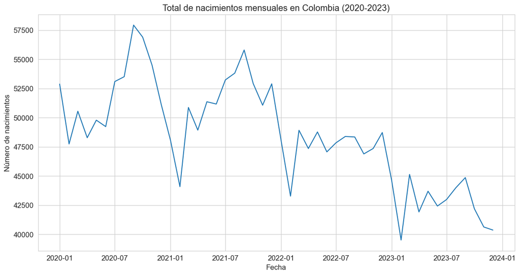

```python
# Visualización de la serie temporal de nacimientos
plt.figure(figsize=(14, 7))
sns.lineplot(x='date', y='total_births', data=monthly_births_national)
plt.title('Total de nacimientos mensuales en Colombia (2020-2023)')
plt.xlabel('Fecha')
plt.ylabel('Número de nacimientos')
plt.grid(True)
plt.show()
```

#### Análisis del gráfico: Total de nacimientos mensuales en colombia (2020-2023)

Este gráfico de línea muestra la evolución del número total de nacimientos mensuales en Colombia desde enero de 2020 hasta finales de 2023.

### Promedio de nacimientos por mes

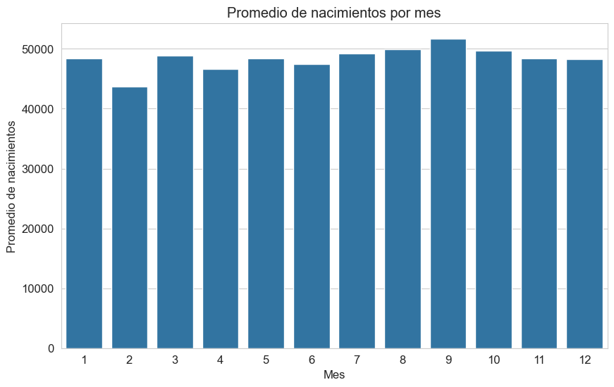

```python
# Análisis de estacionalidad (promedio de nacimientos por mes)
plt.figure(figsize=(10, 6))
sns.barplot(x='MES', y='total_births', data=monthly_births_national.groupby('MES', observed=False)['total_births'].mean().reset_index())
plt.title('Promedio de nacimientos por mes')
plt.xlabel('Mes')
plt.ylabel('Promedio de nacimientos')
plt.show()
```

#### Análisis del gráfico: Promedio de nacimientos por mes

Este gráfico de barras ilustra el promedio de nacimientos por cada mes del año, consolidando los datos de 2020 a 2023. Permite identificar patrones estacionales recurrentes en la natalidad a nivel nacional.

Observaciones clave:

- Pico en septiembre: Se observa consistentemente que septiembre es el mes con el promedio más alto de nacimientos. Esto sugiere que las concepciones tienden a ser más frecuentes alrededor de diciembre/enero, lo que podría estar influenciado por festividades de fin de año o vacaciones.
- Meses bajos: Febrero y abril muestran promedios ligeramente más bajos de nacimientos. Febrero, al ser el mes más corto, naturalmente tiene menos días para nacimientos, lo que podría explicar parte de esta disminución.
- Patrón anual consistente: A pesar de las variaciones interanuales en el número total de nacimientos (como se vio en el gráfico anterior), el patrón estacional mensual se mantiene relativamente constante, lo que refuerza la importancia de las características cíclicas (month_sin, month_cos) en el modelo de predicción.
- Implicaciones para la planificación: Este patrón estacional es crucial para la planificación de recursos en el sector salud (personal, insumos, camas de maternidad) y educación (matrículas escolares) a lo largo del año.

### Distribución de la edad de la madre

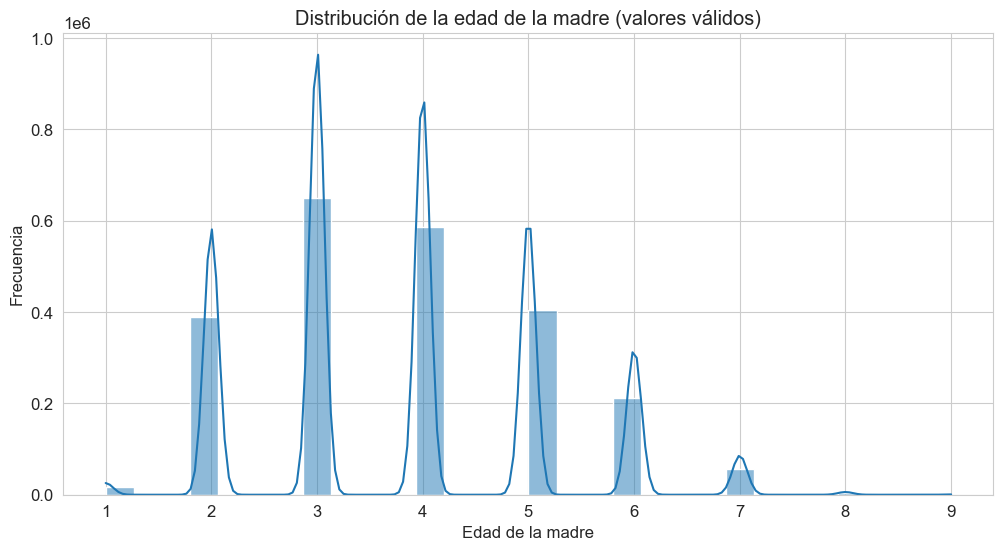

```python
# Distribución de la edad de la madre
# Excluir valores de EDAD_MADRE que mayores al rango 9
df_filtered_age = df_processed[(df_processed['EDAD_MADRE'] <= 9)]

sns.histplot(df_filtered_age['EDAD_MADRE'], bins=30, kde=True)
plt.title('Distribución de la edad de la madre (valores válidos)') # Título ajustado
plt.xlabel('Edad de la madre')
plt.ylabel('Frecuencia')
plt.show()
```

#### Análisis del gráfico: Distribución de la edad de la madre

Este histograma con una estimación de densidad de kernel (KDE) muestra la distribución de la edad de las madres en el conjunto de datos combinado (2020-2023).

Observaciones clave:

- Rango de edad principal: La mayoría de los nacimientos ocurren en madres en un rango de edad que va aproximadamente desde los 20 hasta los 34 años.
- Pico de frecuencia: Se observa un pico de frecuencia alrededor de los 20-24 años (3), lo que indica que esta es la edad más común para la maternidad en Colombia dentro del período analizado.
- Distribución asimétrica: La distribución es ligeramente asimétrica a la derecha, con una cola más larga hacia edades mayores, lo que sugiere que, aunque menos frecuentes, los nacimientos también ocurren en madres de mayor edad.
- Nacimientos en adolescentes: Hay una presencia notable de nacimientos en madres adolescentes (menores de 15-19 años), lo cual es un factor demográfico importante a considerar en políticas de salud pública.

### Distribución del sexo del recién nacido

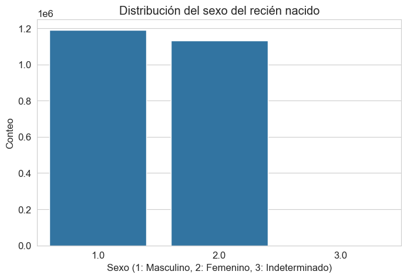

```python
# Distribución del sexo del recién nacido
plt.figure(figsize=(8, 5))
sns.countplot(x='SEXO', data=df_processed)
plt.title('Distribución del sexo del recién nacido')
plt.xlabel('Sexo (1: Masculino, 2: Femenino, 3: Indeterminado)')
plt.ylabel('Conteo')
plt.show()
```

#### Análisis del gráfico: Distribución del sexo del recién nacido

Este gráfico de barras muestra la distribución del sexo de los recién nacidos en el conjunto de datos combinado (2020-2023). La variable SEXO está codificada como 1 para masculino y 2 para femenino.

### Distribución del área de nacimiento

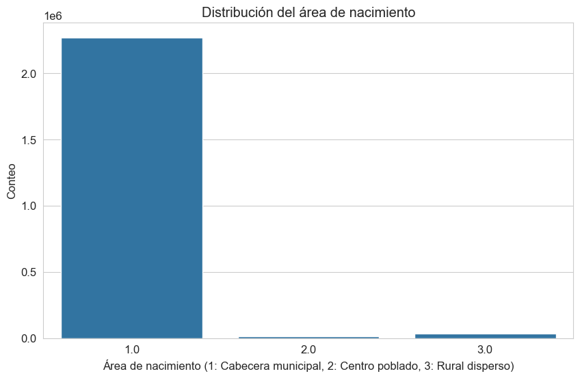

```python
# Distribución del área de nacimiento (AREANAC)
plt.figure(figsize=(10, 6))
sns.countplot(x='AREANAC', data=df_processed)
plt.title('Distribución del área de nacimiento') # Título ajustado
plt.xlabel('Área de nacimiento (1: Cabecera municipal, 2: Centro poblado, 3: Rural disperso)')
plt.ylabel('Conteo')
plt.show()
```

## Análisis a nivel departamental

### Nacimientos mensuales para los 5 departamentos con mayor número de nacimientos

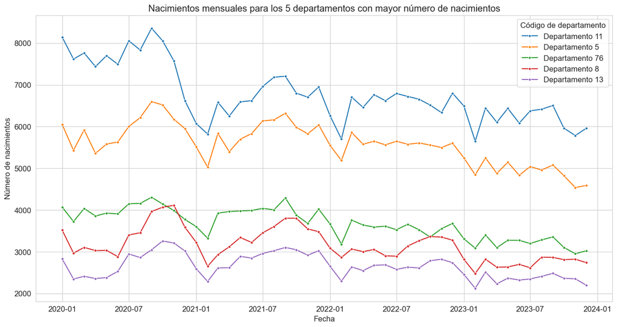

```python
# Nacimientos mensuales para los 5 departamentos con mayor número de nacimientos
top_n_departments = monthly_births_departmental.groupby('COD_DPTO', observed=False)['total_births'].sum().nlargest(5).index

plt.figure(figsize=(16, 8))
for dpto_code in top_n_departments:
    subset = monthly_births_departmental[monthly_births_departmental['COD_DPTO'] == dpto_code]
    sns.lineplot(x='date', y='total_births', data=subset, label=f'Departamento {dpto_code}', marker='o', markersize=4)
plt.title('Nacimientos mensuales para los 5 departamentos con mayor número de nacimientos')
plt.xlabel('Fecha')
plt.ylabel('Número de nacimientos')
plt.legend(title='Código de departamento')
plt.grid(True)
plt.show()
```

#### Análisis del gráfico: Nacimientos mensuales para los 5 departamentos con mayor número de nacimientos

Este gráfico de líneas muestra la evolución mensual de los nacimientos para los cinco departamentos con el mayor número total de nacimientos en Colombia durante el período 2020-2023. Cada línea representa un departamento diferente, identificado por su código.

Observaciones clave:

- Dominio de Bogotá (Departamento 11): El departamento con código 11 (Bogotá D.C.) consistentemente registra el mayor número de nacimientos mensuales, superando significativamente a los demás departamentos. Esto es esperado dada su alta densidad poblacional y concentración de servicios de salud.
- Patrones estacionales departamentales: Aunque cada departamento tiene su propio nivel de nacimientos, se puede observar que la estacionalidad (picos y valles anuales) tiende a ser similar entre ellos, aunque con variaciones en la magnitud. Esto refuerza la idea de que factores temporales comunes influyen en la natalidad a nivel nacional.
- Tendencias individuales: Algunos departamentos muestran tendencias ligeramente diferentes. Por ejemplo, mientras que Bogotá (11) y Antioquia (5) mantienen volúmenes altos, otros departamentos pueden mostrar una menor variabilidad o tendencias más planas.
- Impacto de eventos: Las caídas o repuntes observados en la serie temporal nacional también se reflejan en las series departamentales, aunque con intensidades variables. Esto sugiere que los eventos a gran escala (como la pandemia) afectaron la natalidad en todo el país.

### Distribución de nacimientos por departamento

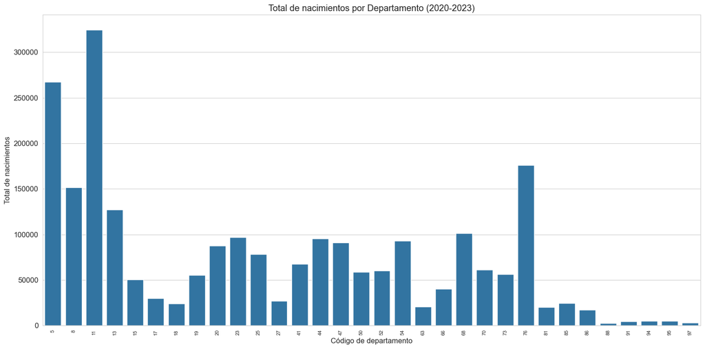

```python
# Distribución de nacimientos por departamento (general)
plt.figure(figsize=(16, 8))
sns.barplot(x='COD_DPTO', y='total_births', data=monthly_births_departmental.groupby('COD_DPTO', observed=False)['total_births'].sum().reset_index().sort_values('total_births', ascending=False))
plt.title('Total de nacimientos por Departamento (2020-2023)')
plt.xlabel('Código de departamento')
plt.ylabel('Total de nacimientos')
plt.xticks(rotation=90, fontsize=8)
plt.tight_layout()
plt.show()
```

#### Análisis del gráfico: Total de nacimientos por departamento

Observaciones clave:

- Disparidad regional: Existe una marcada disparidad en el número de nacimientos entre los departamentos. Unos pocos departamentos concentran la gran mayoría de los nacimientos, mientras que muchos otros tienen volúmenes considerablemente menores.
- Departamentos con mayor natalidad: Los departamentos con códigos 11 (Bogotá D.C.), 5 (Antioquia), 76 (Valle del Cauca) y 8 (Atlántico) se destacan como los de mayor número de nacimientos, lo cual es coherente con su densidad poblacional y desarrollo urbano.
- Departamentos con menor natalidad: Hacia el final del gráfico, se observan departamentos con un número muy bajo de nacimientos, lo que podría corresponder a regiones con menor población o áreas rurales dispersas.
- Importancia para la planificación: La visualización de esta distribución es fundamental para la asignación de recursos y el diseño de políticas públicas a nivel regional, permitiendo identificar las áreas con mayor demanda de servicios relacionados con la natalidad.

# Selección del modelo

Para ambos problemas de predicción (nacional y departamental), se ha elegido el algoritmo RandomForestRegressor (Regresor de Bosque Aleatorio). La justificación para esta elección se basa en las siguientes consideraciones, aplicables a ambos niveles de granularidad:

- Naturaleza de los datos: Aunque los datos tienen un componente temporal, la predicción se puede abordar como un problema de regresión donde las características de entrada son el año y el mes (transformado para capturar la estacionalidad). Los Random Forests son muy efectivos en problemas de regresión con datos tabulares.
- Capacidad para capturar relaciones no lineales: La tasa de natalidad puede estar influenciada por factores complejos y no lineales a lo largo del tiempo (ej. cambios socioeconómicos, políticas). Los Random Forests, al ser un ensamble de árboles de decisión, son capaces de modelar relaciones no lineales y capturar interacciones complejas entre las características sin necesidad de una especificación explícita.
- Robustez a outliers y datos ruidosos: Los árboles de decisión son relativamente robustos a los valores atípicos (outliers) y al ruido en los datos, ya que las divisiones se basan en umbrales y no en la magnitud exacta de los valores. Esto es beneficioso dado que los datos demográficos pueden presentar variaciones.
- Manejo de Características Cíclicas: Al transformar el mes en características seno y coseno, el Random Forest puede interpretar mejor la estacionalidad cíclica sin asumir una relación lineal.
- Menor riesgo de sobreajuste (Overfitting): Aunque un solo árbol de decisión puede sobreajustarse, el Random Forest mitiga este riesgo al promediar las predicciones de múltiples árboles entrenados en diferentes subconjuntos de datos (bagging) y características (feature randomness). Esto resulta en un modelo más generalizable.
- Facilidad de uso y buen rendimiento general: Los Random Forests son relativamente fáciles de implementar y suelen ofrecer un buen rendimiento en una amplia gama de problemas de regresión, sirviendo como una excelente línea base.

```python
# Definir las características (X) y la variable objetivo (y) para el modelo NACIONAL
features_national = ['year_numeric', 'month_sin', 'month_cos']
target_national = 'total_births'

X_national = monthly_births_national[features_national]
y_national = monthly_births_national[target_national]

# Dividir los datos en conjuntos de entrenamiento y prueba (Nacional)
# Se utilizará una división basada en el tiempo: los años anteriores para entrenar, el último año para probar.
train_data_national = monthly_births_national[monthly_births_national['ANO'] < 2023]
test_data_national = monthly_births_national[monthly_births_national['ANO'] == 2023]

X_train_national = train_data_national[features_national]
y_train_national = train_data_national[target_national]

X_test_national = test_data_national[features_national]
y_test_national = test_data_national[target_national]

print(f"Tamaño del conjunto de entrenamiento (Nacional): {len(X_train_national)} muestras")
print(f"Tamaño del conjunto de prueba (Nacional): {len(X_test_national)} muestras")
```

```
Tamaño del conjunto de entrenamiento (Nacional): 36 muestras
Tamaño del conjunto de prueba (Nacional): 12 muestras
```

```python
# Definir las características (X) y la variable objetivo (y) para el modelo DEPARTAMENTAL
features_departmental = ['year_numeric', 'month_sin', 'month_cos'] + [col for col in df_features_departmental.columns if 'DPTO_' in col]
target_departmental = 'total_births'

X_departmental = df_features_departmental[features_departmental]
y_departmental = df_features_departmental[target_departmental]

# Dividir los datos en conjuntos de entrenamiento y prueba (Departamental)
# Se utilizará una división basada en el tiempo: los años anteriores para entrenar, el último año para probar.
train_data_departmental = df_features_departmental[df_features_departmental['ANO'] < 2023]
test_data_departmental = df_features_departmental[df_features_departmental['ANO'] == 2023]

X_train_departmental = train_data_departmental[features_departmental]
y_train_departmental = train_data_departmental[target_departmental]

X_test_departmental = test_data_departmental[features_departmental]
y_test_departmental = test_data_departmental[target_departmental]

print(f"Tamaño del conjunto de entrenamiento (Departamental): {len(X_train_departmental)} muestras")
print(f"Tamaño del conjunto de prueba (Departamental): {len(X_test_departmental)} muestras")

# Verificar que los departamentos en train y test son consistentes
train_departments = [col.replace('DPTO_', '') for col in X_train_departmental.columns if 'DPTO_' in col]
test_departments = [col.replace('DPTO_', '') for col in X_test_departmental.columns if 'DPTO_' in col]

if set(train_departments) != set(test_departments):
    print("\nAdvertencia: Los departamentos presentes en el conjunto de entrenamiento y prueba difieren.")
    print("Departamentos en entrenamiento:", sorted(list(set(train_departments))))
    print("Departamentos en prueba:", sorted(list(set(test_departments))))
    # Esto puede ocurrir si un departamento solo tiene datos en 2023, o solo antes de 2023.
    # El modelo de Random Forest debería manejar esto, pero es una buena observación.
```

```
Tamaño del conjunto de entrenamiento (Departamental): 1152 muestras
Tamaño del conjunto de prueba (Departamental): 384 muestras
```